# Zajęcia 4

# Zajęcia 4

Dzisiejsze zajęcia poprowadzimy w trybie warsztatowym. Postaramy się wybrane dane publiczne.

Proszę pobrać dane geoprzestrzenne nt. województw dostępne pod linkiem:

[envirosolutions.pl - otwarte dane GIS](https://www.envirosolutions.pl/otwarte-dane.html)

Można skopiować i wkleić link:

https://www.envirosolutions.pl/otwarte-dane.html

proszę te dane wypakować w folderze z plikiem notatnika R.

Wczytajmy te dane z pomocą biblioteki sf wskazując plik wojewodztwa.shp. Pozostałe pliki są niezbędne, ale bezpośrednio nie są wskazywane przy otwieraniu.

```r
library(sf)
#woj <- st_read("C:/Users/student/Desktop/zajeciaR/wojewodztwa.shp")
wojewodztwa <- st_read("wojewodztwa.shp")
```

Co nam się wczytało do obiektu sf:

```r
wojewodztwa
```

```
Simple feature collection with 16 features and 29 fields
Geometry type: MULTIPOLYGON
Dimension:     XY
Bounding box:  xmin: 171677.6 ymin: 133223.7 xmax: 861895.7 ymax: 775019.1
CRS:           NA
First 10 features:
     iip_przest                           iip_identy jpt_sjr_ko jpt_kod_je          jpt_nazwa_ jpt_nazw01 jpt_organ_ jpt_orga01
1  PL.PZGIK.200 9bd0c42a-ca40-4b7d-9b5b-81aae3398015        WOJ         16            opolskie       <NA>       <NA>        NZN
2  PL.PZGIK.200 d021c0dd-b22e-4fcd-8444-904c64ec3aa8        WOJ         26      świętokrzyskie       <NA>       <NA>        NZN
3  PL.PZGIK.200 c26354a4-3043-4ca9-9105-df6f0f9c1d93        WOJ         04  kujawsko-pomorskie       <NA>       <NA>        NZN
4  PL.PZGIK.200 4b6c492a-eb04-441d-a92a-f44359c06de7        WOJ         14         mazowieckie       <NA>       <NA>        NZN
5  PL.PZGIK.200 98a63fe6-1e56-4d05-9c47-ab4233f8a6ff        WOJ         24             śląskie       <NA>       <NA>        NZN
6  PL.PZGIK.200 45e7cfc6-6d8b-42ff-acbd-ef1d0a53dacb        WOJ         28 warmińsko-mazurskie       <NA>       <NA>        NZN
7  PL.PZGIK.200 c3f2202a-b491-49c5-a3af-d581108d939a        WOJ         32  zachodniopomorskie       <NA>       <NA>        NZN
8  PL.PZGIK.200 f1ef3856-09ba-4e3d-af9d-a876794d570f        WOJ         02        dolnośląskie       <NA>       <NA>        NZN
```

[output cut: 35 more lines]

Jak widzmy zawiera dane związane z obrysami województw. Szczególną uwagę proszę poświęcić na ostatnią kolumnę “geometry” - jest to specjalna kolumna w danych geoprzestrzennych mówiąza o położeniu i kształcie opisywanego w jednym wierszu obiektu. “MULTIPOLIGON” oznacza, że każde województwo jest opisane kilkoma (lub jednym) wielokątem. Drugą kolumną, na którą należy zwrócić uwagę, jest kolumna “jpt_nazwa_”. Do jednej i do drugiej kolumny możemy się odwoływać przez `$`

dla uproszczenia wybierzmy tylko te kolumny, ponieważ tylko one nam będą potrzebne.

```r
woj <- wojewodztwa[,c("jpt_nazwa_", "geometry")]
```

```r
woj$jpt_nazwa_
```

```
 [1] "opolskie"            "świętokrzyskie"      "kujawsko-pomorskie"  "mazowieckie"         "śląskie"
 [6] "warmińsko-mazurskie" "zachodniopomorskie"  "dolnośląskie"        "wielkopolskie"       "łódzkie"
[11] "podlaskie"           "małopolskie"         "lubuskie"            "podkarpackie"        "lubelskie"
[16] "pomorskie"
```

W prosty sposób wyrysujmy geometrie

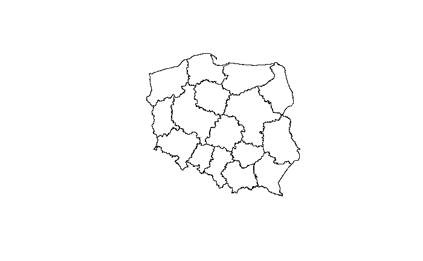

```r
plot(woj[,"geometry"])
```

Ggplot2 pomaga nam ładniej wyrysować granice.

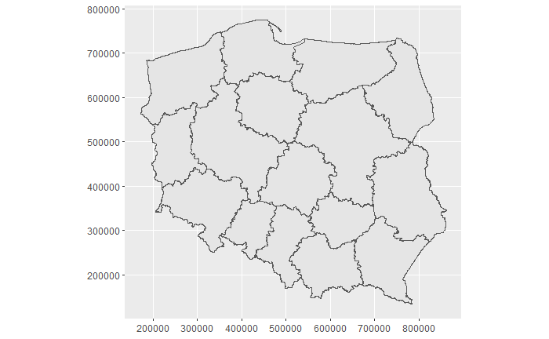

```r
library(ggplot2)
ggplot(woj) + #nowy wykres i na których danych bazujemy
  geom_sf() # dodanie geometrii to wykresu
```

Do prostywych wizualizacji danych nie będziemy potrzebować siatki i podziałki.

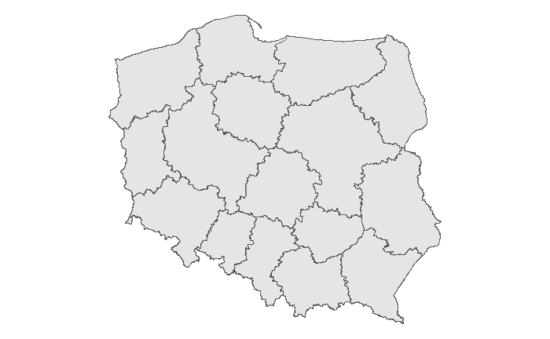

```r
ggplot(woj) +
  geom_sf() +
  theme_void() #upraszczamy wygląd
```

## Od tego miejsca zaczyna się przygotowanie pobranych danych do wizualizacji

Skoro już mamy kształwy województw, pozyskajmy jakieś dane, które są zagregowane po województwach.

Zdarzenia w ruchu drogowym w 2022 z podziałem na województwa

[dane.gov.pl - zdarzenia w ruchu drogowym 2022](https://dane.gov.pl/en/dataset/834,zdarzenia-w-ruchu-drogowym/resource/47302/table)

Można skopiować i wkleić link:

https://dane.gov.pl/en/dataset/834,zdarzenia-w-ruchu-drogowym/resource/47302/table

Za pomocą interfejsu Rstudio “Import Dataset” możemy właściwie wczytać dane. (demo) W przypadku problemów ustawić kodowanie na (locale -> encoding) na “windows-1250”

Poniżej wygenerowana przy tej okazji instrukcja wczytywania pobranych danych (działa u mnie lokalnie, proszę importować za pomocą interfejsu Rstudio)

```r
library(readr)
zd <- read_delim("Zdarzenia_w_ruchu_drogowym_w_2022_r._-_podział_na_województwa.csv",
     delim = ";", escape_double = FALSE, locale = locale(encoding = "windows-1250"),
     trim_ws = TRUE, skip = 3)
```

```r
zd
```

| Województwo | Liczba Wypadkow | Liczba Zabitych | Liczba Rannych | Liczba Kolizji | ...6 | ...7 |
| --- | --- | --- | --- | --- | --- | --- |
| WOJ. DOLNOŚLĄSKIE | 1869 | 138 | 2201 | 33699 | NA | NA |
| WOJ. KUJAWSKO-POMORSKIE | 770 | 103 | 857 | 21681 | NA | NA |
| WOJ. LUBELSKIE | 785 | 121 | 815 | 17142 | NA | NA |
| WOJ. LUBUSKIE | 499 | 63 | 580 | 9900 | NA | NA |
| WOJ. ŁÓDZKIE | 2209 | 164 | 2633 | 23220 | NA | NA |
| WOJ. MAŁOPOLSKIE | 2226 | 102 | 2615 | 26792 | NA | NA |
| WOJ. MAZOWIECKIE | 2896 | 289 | 3398 | 55490 | NA | NA |
| WOJ. OPOLSKIE | 438 | 64 | 513 | 9278 | NA | NA |
| WOJ. PODKARPACKIE | 1062 | 88 | 1264 | 14767 | NA | NA |
| WOJ. PODLASKIE | 333 | 69 | 360 | 11080 | NA | NA |

[output cut: 9 more lines]

Widzimy, że tabela posiada kolumnę województwo, którą trzeba dostosować do danych o kształtach (pozbyć się pierwszych 5 znaków “WOJ.” i zamienić na małe litery). S pomocą przychodzą nam narzędzia z modułu bazowego R i “stringi”.

```r
zd$Województwo
```

```
 [1] "WOJ. DOLNOŚLĄSKIE"        "WOJ. KUJAWSKO-POMORSKIE"  "WOJ. LUBELSKIE"           "WOJ. LUBUSKIE"
 [5] "WOJ. ŁÓDZKIE"             "WOJ. MAŁOPOLSKIE"         "WOJ. MAZOWIECKIE"         "WOJ. OPOLSKIE"
 [9] "WOJ. PODKARPACKIE"        "WOJ. PODLASKIE"           "WOJ. POMORSKIE"           "WOJ. ŚLĄSKIE"
[13] "WOJ. ŚWIĘTOKRZYSKIE"      "WOJ. WARMIŃSKO-MAZURSKIE" "WOJ. WIELKOPOLSKIE"       "WOJ. ZACHODNIOPOMORSKIE"
[17] "Podsumowanie"             NA                         NA
```

```r
library(stringi)
stri_sub(zd$Województwo, from = 6)
```

```
 [1] "DOLNOŚLĄSKIE"        "KUJAWSKO-POMORSKIE"  "LUBELSKIE"           "LUBUSKIE"            "ŁÓDZKIE"
 [6] "MAŁOPOLSKIE"         "MAZOWIECKIE"         "OPOLSKIE"            "PODKARPACKIE"        "PODLASKIE"
[11] "POMORSKIE"           "ŚLĄSKIE"             "ŚWIĘTOKRZYSKIE"      "WARMIŃSKO-MAZURSKIE" "WIELKOPOLSKIE"
[16] "ZACHODNIOPOMORSKIE"  "mowanie"             NA                    NA
```

zapisujemy to do nowej kolumny “NAZWAWOJ”

```r
zd[,"NAZWAWOJ"] <- stri_sub(zd$Województwo, from = 6)
```

```r
zd
```

| Województwo | Liczba Wypadkow | Liczba Zabitych | Liczba Rannych | Liczba Kolizji | ...6 | ...7 | NAZWAWOJ |
| --- | --- | --- | --- | --- | --- | --- | --- |
| WOJ. DOLNOŚLĄSKIE | 1869 | 138 | 2201 | 33699 | NA | NA | DOLNOŚLĄSKIE |
| WOJ. KUJAWSKO-POMORSKIE | 770 | 103 | 857 | 21681 | NA | NA | KUJAWSKO-POMORSKIE |
| WOJ. LUBELSKIE | 785 | 121 | 815 | 17142 | NA | NA | LUBELSKIE |
| WOJ. LUBUSKIE | 499 | 63 | 580 | 9900 | NA | NA | LUBUSKIE |
| WOJ. ŁÓDZKIE | 2209 | 164 | 2633 | 23220 | NA | NA | ŁÓDZKIE |
| WOJ. MAŁOPOLSKIE | 2226 | 102 | 2615 | 26792 | NA | NA | MAŁOPOLSKIE |
| WOJ. MAZOWIECKIE | 2896 | 289 | 3398 | 55490 | NA | NA | MAZOWIECKIE |
| WOJ. OPOLSKIE | 438 | 64 | 513 | 9278 | NA | NA | OPOLSKIE |
| WOJ. PODKARPACKIE | 1062 | 88 | 1264 | 14767 | NA | NA | PODKARPACKIE |
| WOJ. PODLASKIE | 333 | 69 | 360 | 11080 | NA | NA | PODLASKIE |

[output cut: 9 more lines]

Zamieniamy na małe litery

```r
tolower(zd$NAZWAWOJ)
```

```
 [1] "dolnośląskie"        "kujawsko-pomorskie"  "lubelskie"           "lubuskie"            "łódzkie"
 [6] "małopolskie"         "mazowieckie"         "opolskie"            "podkarpackie"        "podlaskie"
[11] "pomorskie"           "śląskie"             "świętokrzyskie"      "warmińsko-mazurskie" "wielkopolskie"
[16] "zachodniopomorskie"  "mowanie"             NA                    NA
```

zapisujemy do kolumny “nazwawoj”

```r
zd[,"nazwawoj"] <- tolower(zd$NAZWAWOJ)
```

Trzeba połączyć ramkę danych (podobnie jak się łączy tabele w SQL) z informacjami o geometrii województw za pomoca merge

Parametry: pierwsza ramka danych druga ramka danych którą kolumnę wykorzystujemy do łączenia z pierwszej ramki którą kolumnę wykorzystujemy do łączenia z drugiej ramki

```r
merge(x=woj, y=zd, by.x="jpt_nazwa_", by.y="nazwawoj")
```

```
Simple feature collection with 16 features and 9 fields
Geometry type: MULTIPOLYGON
Dimension:     XY
Bounding box:  xmin: 171677.6 ymin: 133223.7 xmax: 861895.7 ymax: 775019.1
CRS:           NA
First 10 features:
           jpt_nazwa_             Województwo Liczba Wypadkow Liczba Zabitych Liczba Rannych Liczba Kolizji ...6 ...7
1        dolnośląskie       WOJ. DOLNOŚLĄSKIE            1869             138           2201          33699   NA   NA
2  kujawsko-pomorskie WOJ. KUJAWSKO-POMORSKIE             770             103            857          21681   NA   NA
3           lubelskie          WOJ. LUBELSKIE             785             121            815          17142   NA   NA
4            lubuskie           WOJ. LUBUSKIE             499              63            580           9900   NA   NA
5             łódzkie            WOJ. ŁÓDZKIE            2209             164           2633          23220   NA   NA
6         małopolskie        WOJ. MAŁOPOLSKIE            2226             102           2615          26792   NA   NA
7         mazowieckie        WOJ. MAZOWIECKIE            2896             289           3398          55490   NA   NA
8            opolskie           WOJ. OPOLSKIE             438              64            513           9278   NA   NA
9        podkarpackie       WOJ. PODKARPACKIE            1062              88           1264          14767   NA   NA
10          podlaskie          WOJ. PODLASKIE             333              69            360          11080   NA   NA
             NAZWAWOJ                       geometry
1        DOLNOŚLĄSKIE MULTIPOLYGON (((205901.1 34...
2  KUJAWSKO-POMORSKIE MULTIPOLYGON (((383436.9 61...
3           LUBELSKIE MULTIPOLYGON (((681015.8 42...
4            LUBUSKIE MULTIPOLYGON (((196217.3 44...
5             ŁÓDZKIE MULTIPOLYGON (((435569.2 38...
6         MAŁOPOLSKIE MULTIPOLYGON (((505961.5 23...
7         MAZOWIECKIE MULTIPOLYGON (((517613.9 50...
8            OPOLSKIE MULTIPOLYGON (((351531.4 28...
9        PODKARPACKIE MULTIPOLYGON (((652714.9 26...
10          PODLASKIE MULTIPOLYGON (((672078.5 62...
```

Zweryfikujmy krótko powstałą ramkę danych. Czy właściwe wartości w kolumnie “jpt_nazwa_” odpowiadają właściwym wartościom w kolumnie “Województwo”.

Zapiszmy wynik łączenia ramek i wykonajmy pierwszą wizualizację, korzystając już szablonu zamieszczonego powyżej. Dla przypomnienia

```r
woj.dane <- merge(x=woj, y=zd, by.x="jpt_nazwa_", by.y="nazwawoj")
woj.dane
```

```
Simple feature collection with 16 features and 9 fields
Geometry type: MULTIPOLYGON
Dimension:     XY
Bounding box:  xmin: 171677.6 ymin: 133223.7 xmax: 861895.7 ymax: 775019.1
CRS:           NA
First 10 features:
           jpt_nazwa_             Województwo Liczba Wypadkow Liczba Zabitych Liczba Rannych Liczba Kolizji ...6 ...7
1        dolnośląskie       WOJ. DOLNOŚLĄSKIE            1869             138           2201          33699   NA   NA
2  kujawsko-pomorskie WOJ. KUJAWSKO-POMORSKIE             770             103            857          21681   NA   NA
3           lubelskie          WOJ. LUBELSKIE             785             121            815          17142   NA   NA
4            lubuskie           WOJ. LUBUSKIE             499              63            580           9900   NA   NA
5             łódzkie            WOJ. ŁÓDZKIE            2209             164           2633          23220   NA   NA
6         małopolskie        WOJ. MAŁOPOLSKIE            2226             102           2615          26792   NA   NA
7         mazowieckie        WOJ. MAZOWIECKIE            2896             289           3398          55490   NA   NA
8            opolskie           WOJ. OPOLSKIE             438              64            513           9278   NA   NA
9        podkarpackie       WOJ. PODKARPACKIE            1062              88           1264          14767   NA   NA
10          podlaskie          WOJ. PODLASKIE             333              69            360          11080   NA   NA
             NAZWAWOJ                       geometry
1        DOLNOŚLĄSKIE MULTIPOLYGON (((205901.1 34...
2  KUJAWSKO-POMORSKIE MULTIPOLYGON (((383436.9 61...
3           LUBELSKIE MULTIPOLYGON (((681015.8 42...
4            LUBUSKIE MULTIPOLYGON (((196217.3 44...
5             ŁÓDZKIE MULTIPOLYGON (((435569.2 38...
6         MAŁOPOLSKIE MULTIPOLYGON (((505961.5 23...
7         MAZOWIECKIE MULTIPOLYGON (((517613.9 50...
8            OPOLSKIE MULTIPOLYGON (((351531.4 28...
9        PODKARPACKIE MULTIPOLYGON (((652714.9 26...
10          PODLASKIE MULTIPOLYGON (((672078.5 62...
```

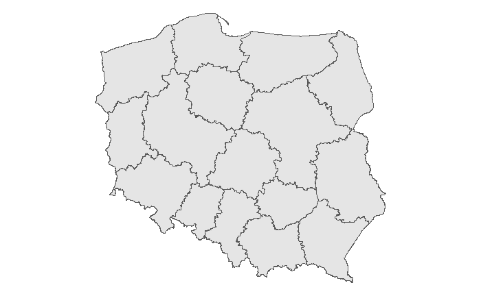

```r
ggplot(woj.dane) +
  geom_sf() +
  theme_void()
```

Zróbmy zatem aby wypełnienie obszarów zależało od wartości w którejś z kolumn

```r
woj.dane$`Liczba Wypadkow`
```

```
 [1] 1869  770  785  499 2209 2226 2896  438 1062  333 1592 1984  649  830 2299  881
```

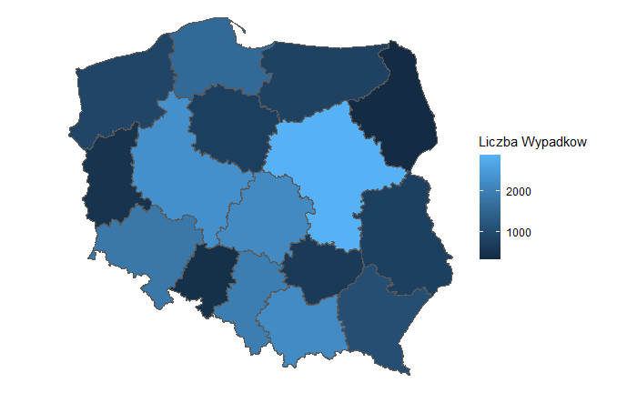

```r
ggplot(woj.dane) +
  geom_sf(aes(fill=`Liczba Wypadkow`)) +
  theme_void()
```

```r
woj.dane$`Liczba Wypadkow`
ggplot(woj.dane) +
  geom_sf(aes(fill=`Liczba Wypadkow`)) +
  theme_void() +
  ggtitle("Liczba wypadków drogowych z podziałem na województwa")
```

[output not shown]

## Zadanie

Pobrać jeszcze inne dane z dane.gov.pl z podziałem na województwa, dokonać ich obróbki i wizualizacji w oparciu o geometrie wykorzystane powyżej.

Można użyć wyszukiwarki i wpisać frazę “na województwa”

```r
library(readr)
dane_rej <- read_delim('Pojazdy_wg_wojewodztw_2023.csv', delim=';', escape_double=FALSE, locale = locale(encoding = "windows-1250"), trim_ws=TRUE)
```

```r
dane_rej <- dane_rej[,!names(dane_rej) %in% c("listopad","grudzień")]
dane_rej$WOJEWÓDZTWO <- tolower(dane_rej$WOJEWÓDZTWO)

dane_m <- merge(x=woj, y=dane_rej, by.x="jpt_nazwa_", by.y = "WOJEWÓDZTWO")
dane_m
```

```
Simple feature collection with 16 features and 11 fields
Geometry type: MULTIPOLYGON
Dimension:     XY
Bounding box:  xmin: 171677.6 ymin: 133223.7 xmax: 861895.7 ymax: 775019.1
CRS:           NA
First 10 features:
           jpt_nazwa_ styczeń  luty marzec kwiecień   maj czerwiec lipiec sierpień wrzesień październik
1        dolnośląskie    9031  8919  11808     9774 10455    10919  10435    10725    10843       11925
2  kujawsko-pomorskie    5597  5576   7382     6224  6650     6633   6390     6445     6361        7025
3           lubelskie    6031  6029   7658     6589  6957     7054   6796     6929     6810        7508
4            lubuskie    3488  3483   4699     3934  4259     4261   4193     4310     4125        4489
5             łódzkie    6883  7202   9296     7894  8263     8233   8097     8097     8091        8474
6         małopolskie   10564 10771  14618    11630 12847    13155  12336    12161    12453       13625
7         mazowieckie   25197 26259  34902    27727 31062    31110  29329    29367    29214       31394
8            opolskie    2500  2675   3504     2884  3098     3297   3006     3190     3003        3279
9        podkarpackie    6035  6068   7674     6331  6980     7309   7014     7372     6762        7456
10          podlaskie    3249  3393   4248     3541  3865     3944   3910     3831     3737        3972
                         geometry
1  MULTIPOLYGON (((205901.1 34...
2  MULTIPOLYGON (((383436.9 61...
3  MULTIPOLYGON (((681015.8 42...
4  MULTIPOLYGON (((196217.3 44...
5  MULTIPOLYGON (((435569.2 38...
6  MULTIPOLYGON (((505961.5 23...
7  MULTIPOLYGON (((517613.9 50...
8  MULTIPOLYGON (((351531.4 28...
9  MULTIPOLYGON (((652714.9 26...
10 MULTIPOLYGON (((672078.5 62...
```

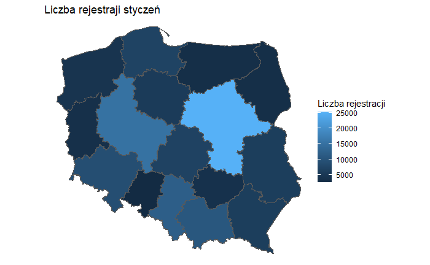

```r
ggplot(dane_m) +
  geom_sf(aes(fill=`styczeń`)) +
  theme_void() +
  ggtitle("Liczba rejestraji styczeń") +
  labs(fill='Liczba rejestracji')
```